# A3: Incarceration

### Authors

Samarth Rao

raosa@uw.edu

### Introduction

For this assignment, I wanted to analyze the relationship between minorities and white people incarcerated from the late 1900s and how this relationship and disparity changes across different locations and city types across the U.S and also in Washington state specifically. Even before analyzing the data, we know that in the United States, black people have the highest rate of incarceration due to racism in our system. However, I wanted to measure the magnitude of this data over the years and how it can be affected across location and different magnitudes of cities. We tend to think that many urban cities, like those in Washington (Seattle, Bellevue) will be better then more rural towns. Analyzing this data, can give us clues to start uncovering where and more importantly what is causing these disparities in different places and test our assumptions. If we understand where to look to see these disparities, where racism could be the prevalent cause in our problematic system, we then have a huge lead as to where to look further to uncover more and fix the underlying issues. That is why I chose to analyze how the location and urbanicity of counties and states can affect the difference in blacks and white’s incarcerated over the united states

This leads us to our big question:

**Q: How the prevalence of racism in our prison systems has changed across different locations and sizes of cities in the United States, as well as in Washington State specifically.**

### Summary

To gain an understanding of our question we can look at some key statistics that give us an insight and sneak peek of our data. Now let’s look through some of these values. We will first start off by looking at the national datapoints. If we confine our data to the most recent date, through some analysis we see that **LA is the state with the highest difference** between black people and white people incarcerated, while **KY has the smallest difference** out all U.S. states. To look further into our question we can look specifically into **Washington state**, to get more local values, and also explore the impact of a county’s urbanicity. Through further analysis we see that **Cook County is the urban county with the highest difference** of black and white people with a value of 3781.While in rural counties, we have **East Baton Rouge Parish being the rural county with the highest difference** with a value of 773. Obviously these data points don’t represent the whole story and are just some specific data points, but it gives a good sneak peak at the analysis we preformed on this data set.

### The Dataset

Who collected the data?

- The data was collected by VERA, Institute of Justice.

How was the data collected or generated?

- The data was collected by combining multiple sources of information that reports data from U.S prisons and jails. These include but are not limited to… Census of Jails, FBI Uniform Crime Reporting Program, Center of Disease Control and more. These organizations report data from jails and prisons in the U.S and are combined to make this data set.

Why was the data collected?

- There are a multitude of reasons that this data set could have been collected for. But the main reason to allow people to make analysis, and conclusions and undercover relationships and data, that be used to help bring justice and fairness to our incarceration system in the United States

How many observations (rows) are in your data?

How many features (columns) are in the data?

- There are 23 features in this data-set.

What, if any, ethical questions or questions of power do you need to consider when working with this data?

- When working with this data, we need to understand that this data represents real people. And us handling this data, and analyzing and making conclusions based on this data, affects and tells a story about people’s lives. So we need to make sure we are not falsely representing these people and misusing the data, and out power with the use of the data.

What are possible limitations or problems with this data?

- There are many possible limitations with this data that can affect our data. This dataset has many missing NA or 0 values, which can severely limit what we can analyze with this data, as there are data points that we need to include and can skew the data. Our data also has a problem: we need to know the reason behind these incarcerations. If we had a feature that showed us the reason for incarceration then we could make a more concrete analysis and further strengthen our claims by tying this in. We also have some inconsistencies in the data that in some of the columns make the different rates not add up to the total properly. This is concerning the whole population or total jail population. A small limitation but a limitation nonetheless is the fact that they only gave us the state abbreviations in the state feature. This made it a little harder to make maps and combine them with locations to analyze the data per location. Providing both would allow us more options and make it easier to relate to multiple-location data.

### Trends Over Time Chart

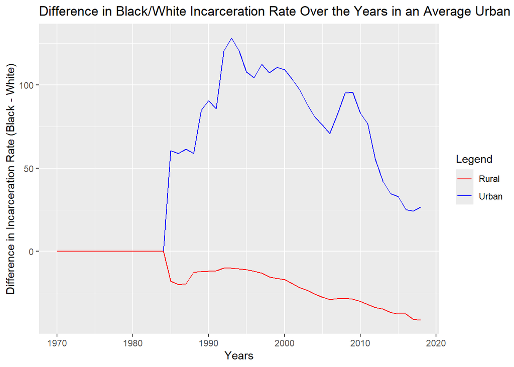

#### Purpose

By showing this chart we can see how the higher disproportionate rate of blacks arrested over white has and have been changing over the years in different city environments and populations. It lets us see the trend of this difference over the years behaves differently in the average urban city and the average rural cities in Washington State. From this chart we can analyze the relationship between the red and blue lines to see when and where the disproportionate rates of blacks incarcerated are more common in Washington State.

*Note: We went with the average to combat the fact that we had more rural data entries than urban data entries.*

### Variable Comparison Chart

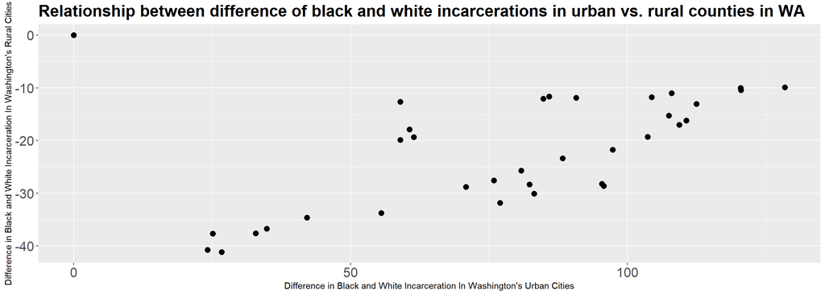

#### Insights

- Here we do see a relationship between the lines, as the trend line that would fit this graph, would have an upwards (positive) slope. This means that there is a positive relation between the two axis.
- If we decipher this trend and apply it to the data, it means we see a positive trend as the disparity in incarceration between black people and white people go up in Washington’s urban cities, then they also tend to go up in Washington’s rural cities.
- While we do see with the graph we made, and it is a suitable conclusion, we run into another one of the limits with only using the data-set. Without further analysis into this topic, understanding more and looking at more features in-depth we cannot tell if the correlation is caused by the increase in urban disparity, or if it is just a coiencedence in the data-set we are looking at.

### Map

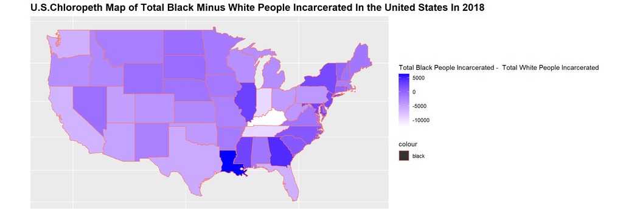

#### Purpose

If we remember back to the beginning of the report, our main question that we want to answer is understanding the magnitude of this disparity of more black people incarcerated and how it is related to the location and urbanity of the location. This choropleth map helps us answer the first part of this question. We can understand how the difference changes across locations and more specifically different states. We can see how states that are darker have a higher value for the difference than the lighter states. This allows us to make an analysis and clearly see where racism could be prevalent in our incarceration system.

#### Insights

- From this chart we do see an interesting pattern with the coloration of the states.
- We can see how the states as we go towards the east, and upper mid east start to get darker. The states on the west and mid west do have a few darker states, and semi dark states, but we see this trend more on the eastern side of the map. On the western side of the map and southwest we see more lighter colors that represent negative numbers and show how those states have a higher amount of white people in jail than black people.
- We can see in what cluster of states near the southeast have a higher disparity between balcks in jail with a lot more black people in jail. If we wanted to see what was causing the disparity in our system then we could start by looking at the system in those areas.